# Basic regression examples using GPFlow

After defining the parameters the model is compiled, fitted to the data and can be used to predict the estimated function for a given intervall. A more detailed description of the hyperparameters can be found in http://www.gaussianprocess.org/gpml/chapters/RW.pdf or https://drafts.distill.pub/gp/

```python
# We will use the simplest form of GP model, exact inference
class ExactGPModel(gpytorch.models.ExactGP):
    def __init__(self, train_x, train_y, likelihood):
        super(ExactGPModel, self).__init__(train_x, train_y, likelihood)
        self.mean_module = gpytorch.means.ConstantMean()
        self.covar_module = gpytorch.kernels.ScaleKernel(gpytorch.kernels.MaternKernel(nu=2.5))

    def forward(self, x):
        mean_x = self.mean_module(x)
        covar_x = self.covar_module(x)
        return gpytorch.distributions.MultivariateNormal(mean_x, covar_x)

# initialize likelihood and model
likelihood = gpytorch.likelihoods.GaussianLikelihood()
model = ExactGPModel(X_sample, Y_sample, likelihood)
```

```python
# Find optimal model hyperparameters
model.train()
likelihood.train()

# Use the adam optimizer
optimizer = torch.optim.Adam([
    {'params': model.parameters()},  # Includes GaussianLikelihood parameters
], lr=0.1)

# "Loss" for GPs - the marginal log likelihood
mll = gpytorch.mlls.ExactMarginalLogLikelihood(likelihood, model)

training_iter = 50
for i in range(training_iter):
    # Zero gradients from previous iteration
    optimizer.zero_grad()
    # Output from model
    output = model(X_sample)
    # Calc loss and backprop gradients
    loss = -mll(output, Y_sample)
    loss.backward()
    print('Iter %d/%d - Loss: %.3f   log_lengthscale: %.3f   log_noise: %.3f' % (
        i + 1, training_iter, loss.item(),
        model.covar_module.base_kernel.log_lengthscale.item(),
        model.likelihood.log_noise.item()
    ))
    optimizer.step()
```

```
Iter 1/50 - Loss: 1.128   log_lengthscale: -0.367   log_noise: -0.367
Iter 2/50 - Loss: 1.092   log_lengthscale: -0.439   log_noise: -0.439
Iter 3/50 - Loss: 1.048   log_lengthscale: -0.514   log_noise: -0.514
Iter 4/50 - Loss: 1.031   log_lengthscale: -0.585   log_noise: -0.590
Iter 5/50 - Loss: 0.995   log_lengthscale: -0.659   log_noise: -0.668
Iter 6/50 - Loss: 0.961   log_lengthscale: -0.717   log_noise: -0.747
Iter 7/50 - Loss: 0.984   log_lengthscale: -0.780   log_noise: -0.827
Iter 8/50 - Loss: 0.952   log_lengthscale: -0.848   log_noise: -0.909
Iter 9/50 - Loss: 0.921   log_lengthscale: -0.911   log_noise: -0.992
Iter 10/50 - Loss: 0.891   log_lengthscale: -0.953   log_noise: -1.076
Iter 11/50 - Loss: 0.873   log_lengthscale: -0.990   log_noise: -1.162
Iter 12/50 - Loss: 0.835   log_lengthscale: -1.011   log_noise: -1.248
Iter 13/50 - Loss: 0.827   log_lengthscale: -1.009   log_noise: -1.335
Iter 14/50 - Loss: 0.844   log_lengthscale: -0.994   log_noise: -1.423
Iter 15/50 - Loss: 0.789   log_lengthscale: -0.974   log_noise: -1.511
Iter 16/50 - Loss: 0.799   log_lengthscale: -0.948   log_noise: -1.599
Iter 17/50 - Loss: 0.793   log_lengthscale: -0.917   log_noise: -1.688
Iter 18/50 - Loss: 0.792   log_lengthscale: -0.889   log_noise: -1.776
Iter 19/50 - Loss: 0.747   log_lengthscale: -0.891   log_noise: -1.864
Iter 20/50 - Loss: 0.707   log_lengthscale: -0.895   log_noise: -1.953
Iter 21/50 - Loss: 0.713   log_lengthscale: -0.907   log_noise: -2.042
Iter 22/50 - Loss: 0.696   log_lengthscale: -0.904   log_noise: -2.131
Iter 23/50 - Loss: 0.671   log_lengthscale: -0.900   log_noise: -2.220
Iter 24/50 - Loss: 0.672   log_lengthscale: -0.881   log_noise: -2.310
Iter 25/50 - Loss: 0.632   log_lengthscale: -0.859   log_noise: -2.402
Iter 26/50 - Loss: 0.560   log_lengthscale: -0.823   log_noise: -2.494
Iter 27/50 - Loss: 0.633   log_lengthscale: -0.794   log_noise: -2.588
Iter 28/50 - Loss: 0.618   log_lengthscale: -0.754   log_noise: -2.682
Iter 29/50 - Loss: 0.663   log_lengthscale: -0.713   log_noise: -2.777
Iter 30/50 - Loss: 0.622   log_lengthscale: -0.673   log_noise: -2.871
Iter 31/50 - Loss: 0.607   log_lengthscale: -0.630   log_noise: -2.965
Iter 32/50 - Loss: 0.494   log_lengthscale: -0.585   log_noise: -3.060
Iter 33/50 - Loss: 0.513   log_lengthscale: -0.553   log_noise: -3.155
Iter 34/50 - Loss: 0.440   log_lengthscale: -0.542   log_noise: -3.251
Iter 35/50 - Loss: 0.498   log_lengthscale: -0.535   log_noise: -3.348
Iter 36/50 - Loss: 0.380   log_lengthscale: -0.535   log_noise: -3.444
Iter 37/50 - Loss: 0.353   log_lengthscale: -0.538   log_noise: -3.542
Iter 38/50 - Loss: 0.510   log_lengthscale: -0.540   log_noise: -3.641
Iter 39/50 - Loss: 0.554   log_lengthscale: -0.529   log_noise: -3.738
Iter 40/50 - Loss: 0.462   log_lengthscale: -0.493   log_noise: -3.835
Iter 41/50 - Loss: 0.534   log_lengthscale: -0.457   log_noise: -3.931
Iter 42/50 - Loss: 0.360   log_lengthscale: -0.412   log_noise: -4.026
Iter 43/50 - Loss: 0.329   log_lengthscale: -0.390   log_noise: -4.122
Iter 44/50 - Loss: 0.307   log_lengthscale: -0.392   log_noise: -4.219
Iter 45/50 - Loss: 0.386   log_lengthscale: -0.412   log_noise: -4.316
Iter 46/50 - Loss: 0.449   log_lengthscale: -0.439   log_noise: -4.412
Iter 47/50 - Loss: 0.258   log_lengthscale: -0.454   log_noise: -4.508
Iter 48/50 - Loss: 0.304   log_lengthscale: -0.443   log_noise: -4.605
Iter 49/50 - Loss: 0.217   log_lengthscale: -0.416   log_noise: -4.701
Iter 50/50 - Loss: 0.267   log_lengthscale: -0.383   log_noise: -4.797
```

```python
# Get into evaluation (predictive posterior) mode
model.eval()
likelihood.eval()

# Test points are regularly spaced along [0,1]
# Make predictions by feeding model through likelihood
with torch.no_grad(), gpytorch.fast_pred_var():
    test_x = torch.linspace(0, 1, 51)
    observed_pred = likelihood(model(X))
```

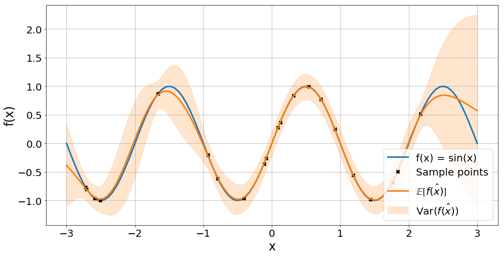

```python
# Get upper and lower confidence bounds
lower, upper = observed_pred.confidence_region()
plot2D(lower.detach().numpy(), upper.detach().numpy(), [X.numpy(), Y_true.numpy(), 'f(x) = sin(x)'], [X_sample.numpy(), Y_sample.numpy(), 'Sample points', 'kx'], [X.numpy(), observed_pred.mean.numpy(), '$\mathbb{E[}\hat{f(x)}\mathbb{]}$'])
```

## Part 2 - Estimation of a Gaussian Process based posterior on existing, noisy data

This example will estimate a Gaussian Process (GP) posterior based on a given, randomly chosen, sample set. The set contains $N=20$ observations of an unknown function. This function could be anything but we assume its evaluation to be expensive which is why we represent it by a surrogate function (the Gaussian Process). Assuming that we tackle a real world problem we add Gaussian white noise $\epsilon$ with zero mean and variance $\sigma_n^2=0.1$ to the data. The ground truth we try to estimate is a sinus of the form \begin{equation*} y_{true} = \sin(2\pi f) \end{equation*} With a frequency of $0.5Hz$.

The final measurement model will be \begin{equation*} y_i = \sin(2\pi f x_i) + \epsilon\\ \epsilon \sim \mathcal{N}(0,\sigma_n^2) \end{equation*} leading to a set of form $\{x_i,y_i\}$ and $i = [1,..., 20]$

```python
# Change noise parameter
sigma_n = 0.1
# Construct models with initial guess
k = gpflow.kernels.Matern52(1, lengthscales=0.3)
m = gpflow.models.GPR(X_sample, Y_sample, kern=k)
m.likelihood.variance = sigma_n
m.compile()
# Print out model
m
```

```
WARNING:gpflow.logdensities:Shape of x must be 2D at computation.
```

|  | class | prior | transform | trainable | shape | fixed_shape | value |
| --- | --- | --- | --- | --- | --- | --- | --- |
| GPR/kern/lengthscales | Parameter | None | +ve | True | () | True | 0.3 |
| GPR/kern/variance | Parameter | None | +ve | True | () | True | 1.0 |
| GPR/likelihood/variance | Parameter | None | +ve | True | () | True | 0.1 |

```python
# Predict with model
mean, var = m.predict_y(X)
# Plot posterior
fig = plot2D(mean, var, [X, Y_true, 'f(x) = sin(x)'], [X, mean, '$\mathbb{E[}\hat{f(x)}\mathbb{]}$'], [X_sample, Y_sample, 'Sample points', 'kx'])
```

[output not shown]

[output not shown]

This parameterization is significantly different from the intuition. Intuitively one would add noise to the sample set but not change the likelihood parameter. While this is also a valid thing to do it adds a second level of noise to the data which would be accounted for by parameterizing the GP correctly.

The following plot shows what happens if the GP is parameterized as in Part 1 and noise is added to the data:

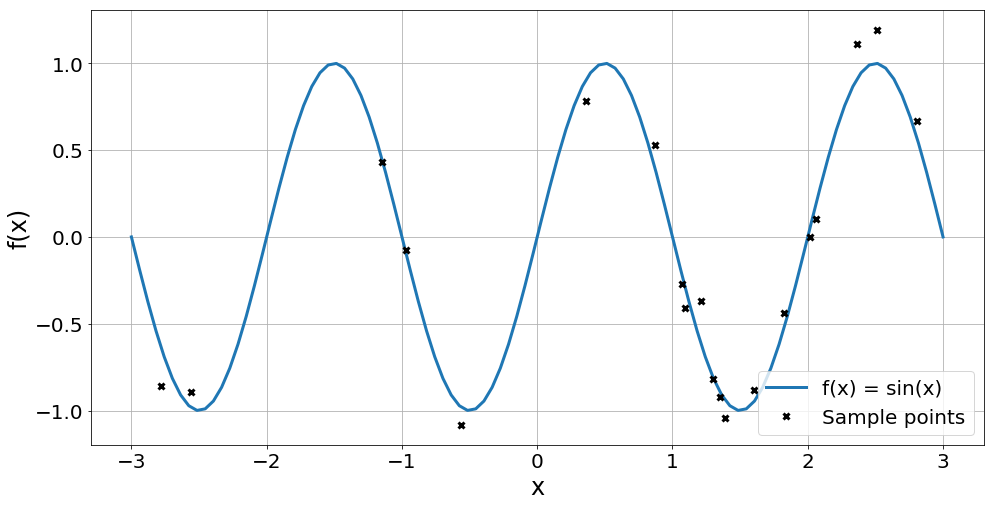

```python
# Set some parameters
sigma_n = 0.1
# np.random.randn(N,1):
# Create an array of the given shape and populate it with random samples from a uniform distribution over [0, 1).
noise = np.random.randn(N,1) * sigma_n
Y_noise = Y_sample + noise

fig = plot2D(None, None, [X, Y_true, 'f(x) = sin(x)'], [X_sample, Y_noise, 'Sample points', 'kx'])
```

```python
# Change noise parameter
sigma_n = 0.0
# Construct models with initial guess
k = gpflow.kernels.Matern52(1, lengthscales=0.3)
m = gpflow.models.GPR(X_sample, Y_noise, kern=k)
m.likelihood.variance = sigma_n
m.compile()
# Print out model
m
```

```
WARNING:gpflow.logdensities:Shape of x must be 2D at computation.
```

|  | class | prior | transform | trainable | shape | fixed_shape | value |
| --- | --- | --- | --- | --- | --- | --- | --- |
| GPR/kern/lengthscales | Parameter | None | +ve | True | () | True | 0.3 |
| GPR/kern/variance | Parameter | None | +ve | True | () | True | 1.0 |
| GPR/likelihood/variance | Parameter | None | +ve | True | () | True | 0.0 |

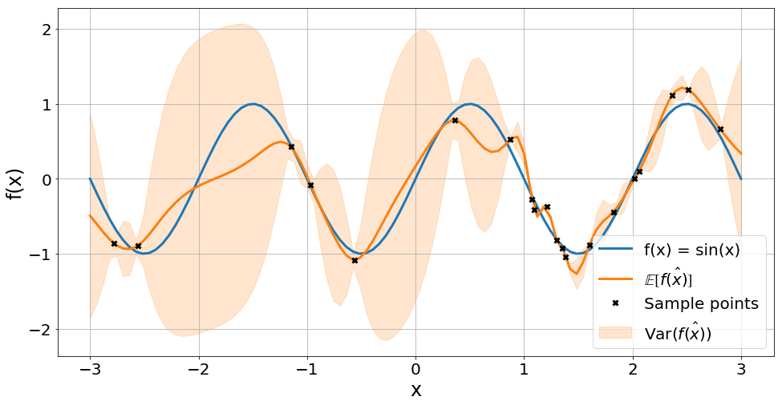

```python
# Predict with model
mean, var = m.predict_y(X)
# Plot posterior
fig = plot2D(mean, var, [X, Y_true, 'f(x) = sin(x)'], [X, mean, '$\mathbb{E[}\hat{f(x)}\mathbb{]}$'], [X_sample, Y_noise, 'Sample points', 'kx'])
```

## Part 3 - Progression of a Gaussian Process posterior based on sequential data

```
WARNING:gpflow.logdensities:Shape of x must be 2D at computation.
WARNING:gpflow.logdensities:Shape of x must be 2D at computation.
WARNING:gpflow.logdensities:Shape of x must be 2D at computation.
WARNING:gpflow.logdensities:Shape of x must be 2D at computation.
WARNING:gpflow.logdensities:Shape of x must be 2D at computation.
```

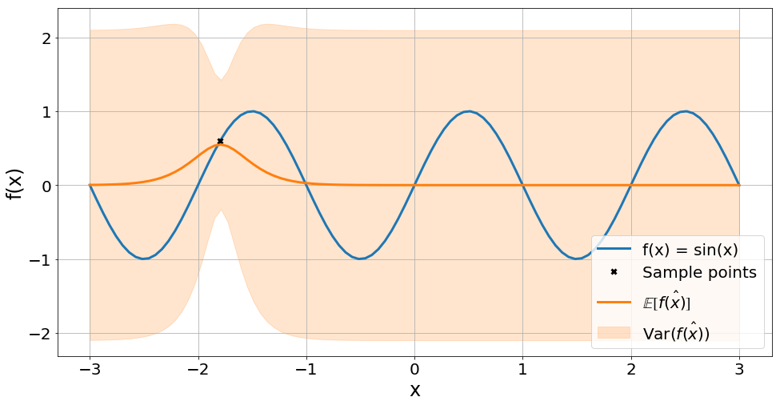

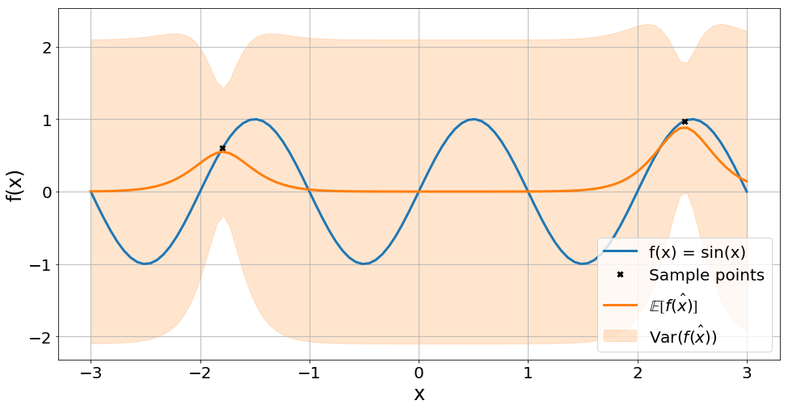

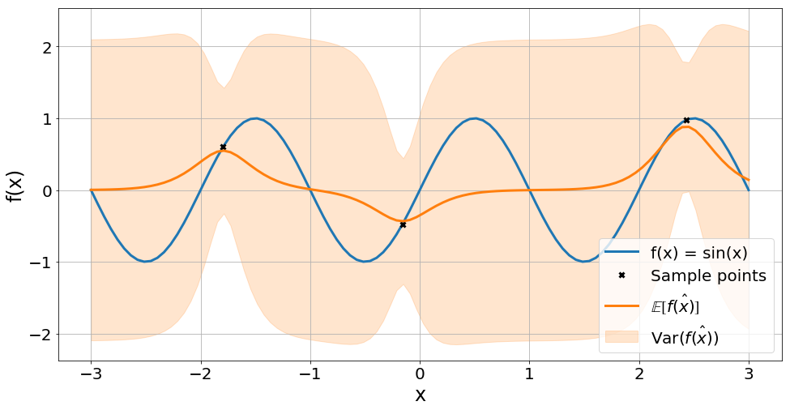

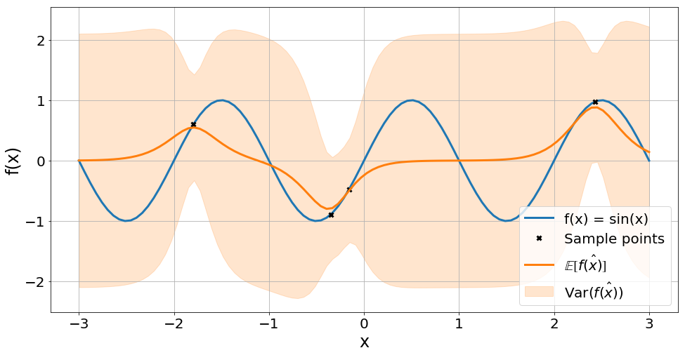

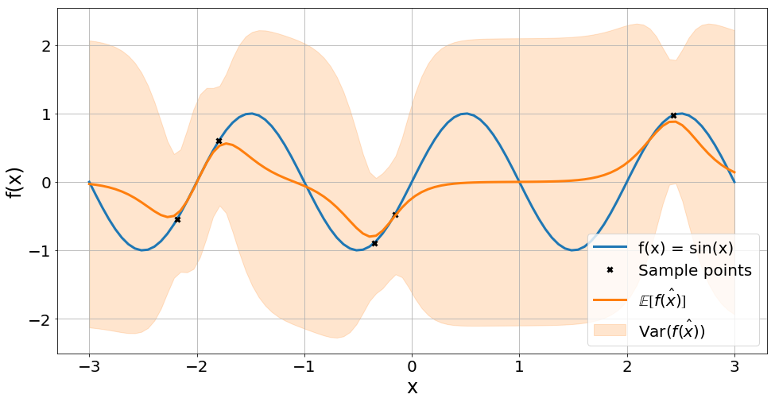

```python
# Set some parameters
k = gpflow.kernels.Matern52(1, lengthscales=0.3)
N_samples = 5
sigma_n = 0.1
f = 0.5 # Frequency for ground truth function

# Build data sets
X = np.linspace(-3., 3., 100).reshape(100, 1)
Y_true = np.sin(X * (2 * math.pi * f))

X_sample = np.array([])
for i in range(N_samples):
    X_sample = np.append(X_sample, np.random.uniform(-3.,3.,(1,1))).reshape(i+1,1)
    Y_sample = np.sin(X_sample * (2 * math.pi * f))

    # Estimate model on samples assuming they distorted by noise
    m = gpflow.models.GPR(X_sample, Y_sample, kern=k)
    m.likelihood.variance = sigma_n
    m.compile()

    # Predict with model
    mean, var = m.predict_y(X)

    # Plot
    plot2D(mean, var, [X, Y_true, 'f(x) = sin(x)'], [X_sample, Y_sample, 'Sample points', 'kx'],
           [X, mean, '$\mathbb{E[}\hat{f(x)}\mathbb{]}$'])

plt.show()
```

The posterior is fitted to the observations each time a sample is added to the set.